# R-Lab: System Monitoring

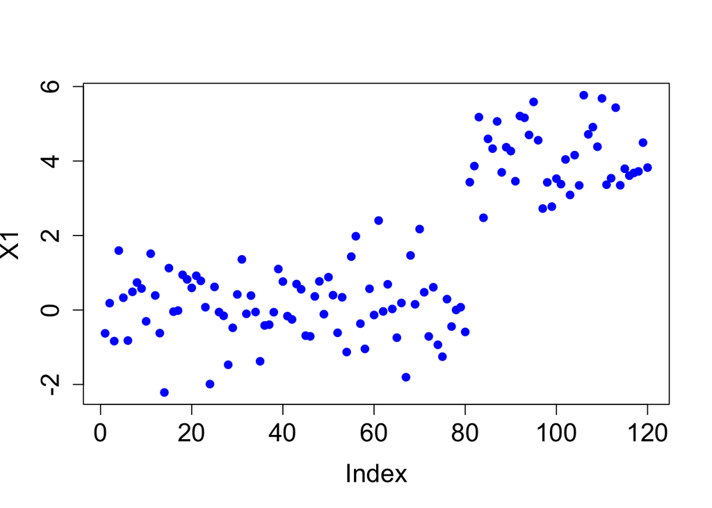

```r
set.seed(1)
X1 <- c( rnorm( 40, mean = 0, sd = 1), rnorm( 40, mean = 0, sd = 1), rnorm( 40, mean = 4, sd = 1) )
plot(X1,type="p",pch = 20, col = "blue",cex.axis=1.5,cex.lab=1.5, cex = 1.5)
```

The monitor R function is defined as follow, and we will apply the function to multiple data sets. The Monitoring function take two data sets, the first one being the reference data, and the second one being the real-time data points. The window size also should be provided. The function returns a few monitoring statistics for each real-time data point, and the importance score of each variable.

```r
library(dplyr)
library(tidyr)
library(randomForest)
library(ggplot2)

theme_set(theme_gray(base_size = 15) )

# define monitoring function. data0: reference data; data.real.time: real-time data; wsz: window size
Monitoring <- function( data0, data.real.time, wsz ){
  num.data.points <- nrow(data.real.time)
  stat.mat <- NULL
  importance.mat <- NULL

  for( i in 1:num.data.points  ){
    # at the start of monitoring, when real-time data size is small than the window size, combine the real-time data points
    # and random samples from the reference data to form a data set of wsz
    if(i<wsz){
      sample.size.from.reference <- wsz - i
      sample.reference <- data0[ sample(nrow(data0),sample.size.from.reference,replace = TRUE), ]
      current.real.time.data <- rbind( sample.reference, data.real.time[1:i,,drop=FALSE]   )
    }else{
      current.real.time.data <-  data.real.time[(i-wsz+1):i,,drop=FALSE]
    }
    current.real.time.data$class <- 1
    data <- rbind( data0, current.real.time.data )
    colnames(data) <- c(paste0("X",1:(ncol(data)-1)),"Class")
    data$Class <- as.factor(data$Class)

    # apply random forests to the data
    my.rf <- randomForest(Class ~.,sampsize=c(wsz,wsz), data=data)

    # get importance score
    importance.mat <- rbind( importance.mat, t( my.rf$importance  ) )
    # get monitoring statistics
    ooblist <- my.rf[5]
    oobcolumn=matrix(c(ooblist[[1]]),2:3)
    ooberrornormal= (oobcolumn[,3])[1]
    ooberrorabnormal=(oobcolumn[,3])[2]

    temp=my.rf[6]
    p1vote <- mean( temp$votes[,2][ (nrow(data0)+1) : nrow(data) ] )

    this.stat <- c(ooberrornormal,ooberrorabnormal,p1vote)
    stat.mat <- rbind(stat.mat, this.stat)
  }
  result <- list( importance.mat = importance.mat,  stat.mat = stat.mat)
  return(result)
}
```

First consider a 2-dimesional data. The reference data follow a normal distribution with mean of 0 and standard deviation of 1. The real-time data come from two distributions. The first 100 data points have the same distribution as the reference data, while the second 100 data points have the second variable changed with mean of 2. Note we label the reference data with class 0 and the real-time data with class 1, regardless what distributions they belong to.

```r
# data generation
# sizes of reference data, real-time data without change, and real-time data with changes
length0 <- 100
length1 <- 100
length2 <- 100

# 2-dimension
dimension <- 2

# reference data
data0 <- rnorm( dimension * length0, mean = 0, sd = 1)
# real-time data with no change
data1 <- rnorm( dimension * length2, mean = 0, sd = 1)
# real-time data different from the reference data in the second the variable
data2 <- cbind( V1 = rnorm( 1 * length1, mean = 0, sd = 1), V2 = rnorm( 1 * length1, mean = 2, sd = 1) )


# convert to data frame
data0 <- matrix(data0, nrow = length0, byrow = TRUE) %>% as.data.frame()
data1 <- matrix(data1, nrow = length2, byrow = TRUE) %>% as.data.frame()
data2 <- data2 %>% as.data.frame()

# assign variable names
colnames( data0 ) <- paste0("X",1:ncol(data0))
colnames( data1 ) <- paste0("X",1:ncol(data1))
colnames( data2 ) <- paste0("X",1:ncol(data2))

# assign reference data with class 0 and real-time data with class 1
data0 <- data0 %>% mutate(class = 0)
data1 <- data1 %>% mutate(class = 1)
data2 <- data2 %>% mutate(class = 1)

# real-time data consists of normal data and abnormal data
data.real.time <- rbind(data1,data2)
```

Here is a plot of the first 100 real-time data points wih the reference data points. The two sets of data points are similar.

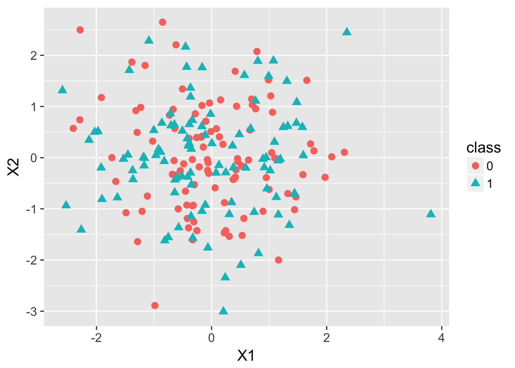

```r
data.plot <- rbind( data0, data1 ) %>% mutate(class = factor(class))
ggplot(data.plot, aes(x=X1, y=X2, shape = class, color=class)) +
  geom_point(size=3)
```

Here is a plot of the second 100 real-time data points wih the reference data points. It can be seen that for the real-time data set, X_2 has changed mean from 0 to 2.

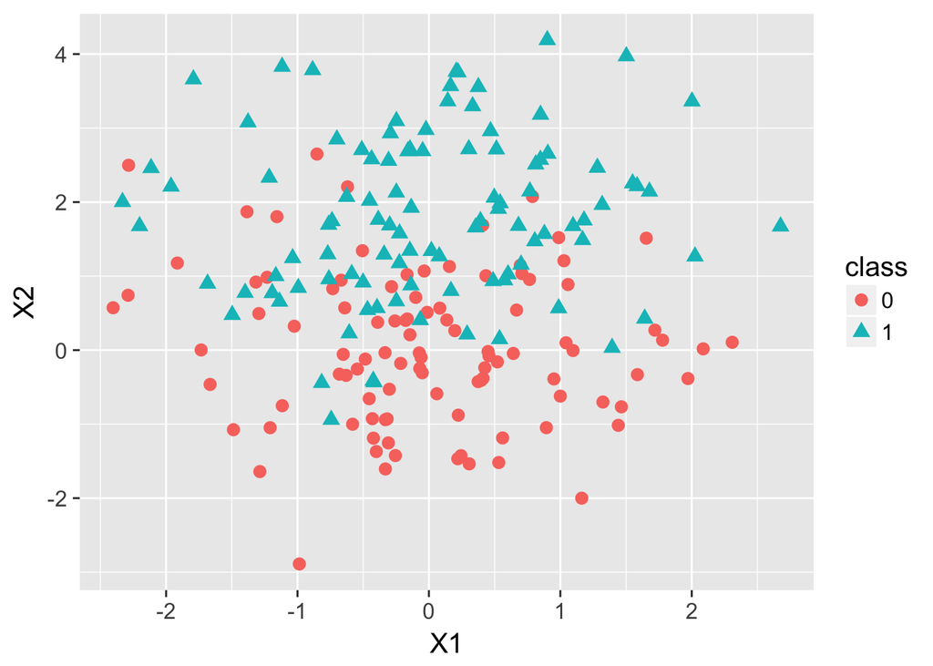

```r
data.plot <- rbind( data0, data2 ) %>% mutate(class = factor(class))
ggplot(data.plot, aes(x=X1, y=X2, shape = class, color=class)) +
  geom_point(size=3)
```

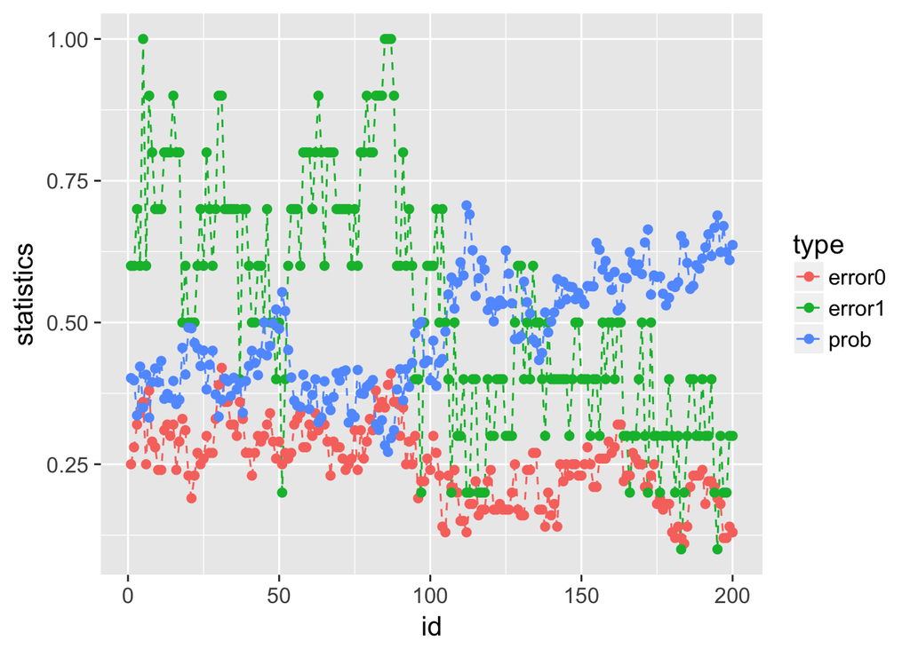

```r
wsz <- 10
result <- Monitoring( data0, data.real.time, wsz )
stat.mat <- result$stat.mat
importance.mat <- result$importance.mat

# plot different monitor statistics
stat.mat <- data.frame(stat.mat)
stat.mat$id <- 1:nrow(stat.mat)
colnames(stat.mat) <- c("error0","error1","prob","id")
stat.mat <- stat.mat %>% gather(type, statistics, error0,error1,prob)
ggplot(stat.mat,aes(x=id,y=statistics,color=type)) + geom_line(linetype = "dashed") + geom_point() + geom_point(size=2)
```

Next consider fault diagnosis. Variable importance scores from the two variables from the random forests are plotted. The importance scores of x_2 significantly increase after the 100th point. This indicates that x_2 plays an important role in improving the classification and may be responsible for the changed signal.

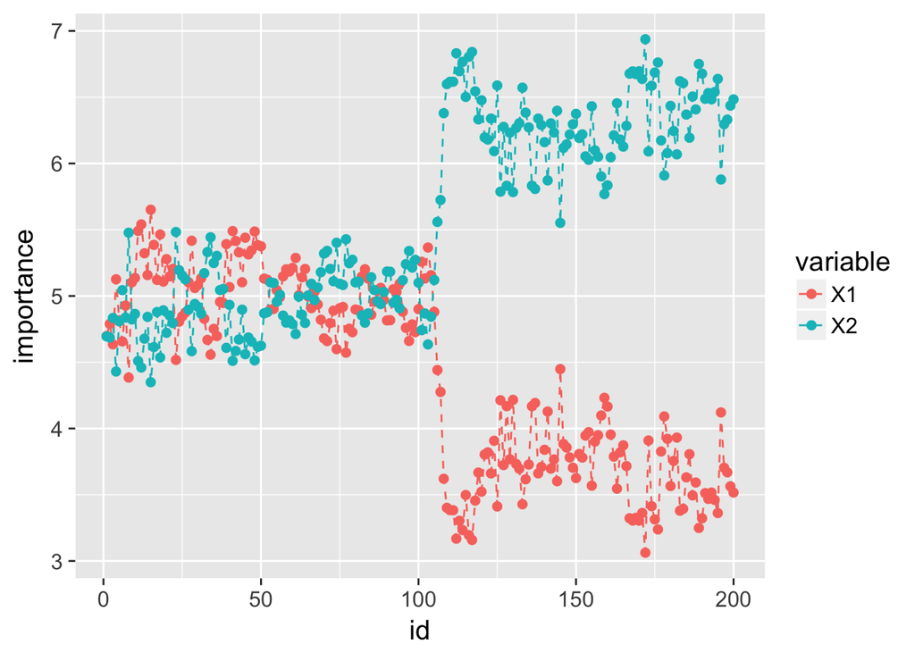

```r
# plot importance scores for diagnosis
importance.mat <- data.frame(importance.mat)
importance.mat$id <- 1:nrow(importance.mat)
colnames(importance.mat) <- c("X1","X2","id")
importance.mat <- importance.mat %>% gather(variable, importance,X1,X2)

ggplot(importance.mat,aes(x=id,y=importance,color=variable)) + geom_line(linetype = "dashed")  + geom_point(size=2)
```

The size of the window for monitoring is an important parameter. Here the window size is increased to 20. The monitoring statistics and importance scores are replotted. Compared to the previous result with window size of 10, the monitoring statistics on the changed real-time data points have a clearer increase from the un-changed real-time data. Similarly, the increase of the importance score of X_2 is stronger. However, the change of the monitoring statistics and importance scores is sligtly slower than the change from a smaller window. Therefore, a large window size can lead to more confident alert, but with a slower speed.

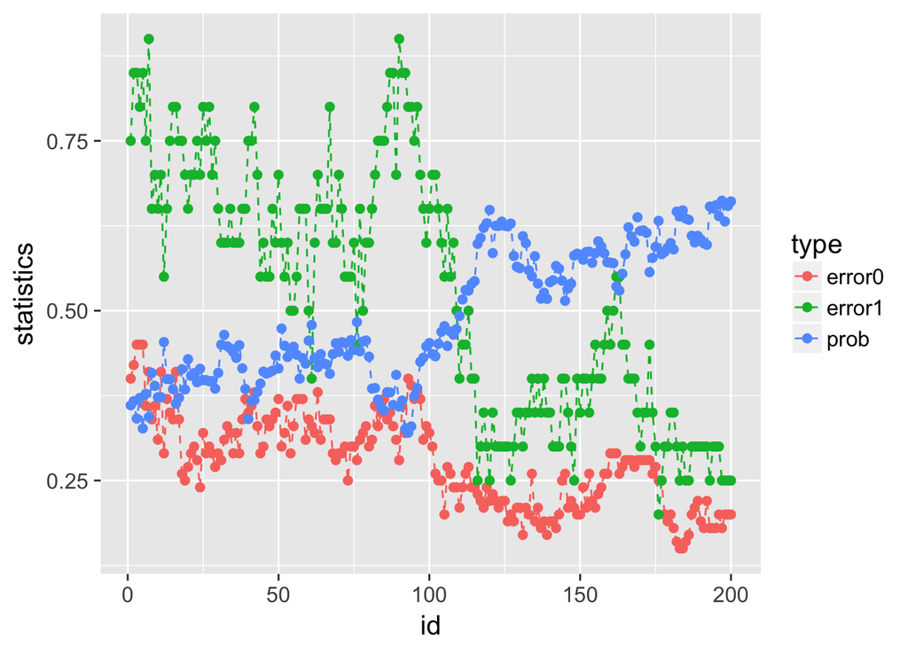

```r
# change window size to 20
wsz <- 20
result <- Monitoring( data0, data.real.time, wsz )
stat.mat <- result$stat.mat
importance.mat <- result$importance.mat

# plot different monitor statistics
stat.mat <- data.frame(stat.mat)
stat.mat$id <- 1:nrow(stat.mat)
colnames(stat.mat) <- c("error0","error1","prob","id")
stat.mat <- stat.mat %>% gather(type, statistics, error0,error1,prob)
ggplot(stat.mat,aes(x=id,y=statistics,color=type))+ geom_line(linetype = "dashed") + geom_point() + geom_point(size=2)
```

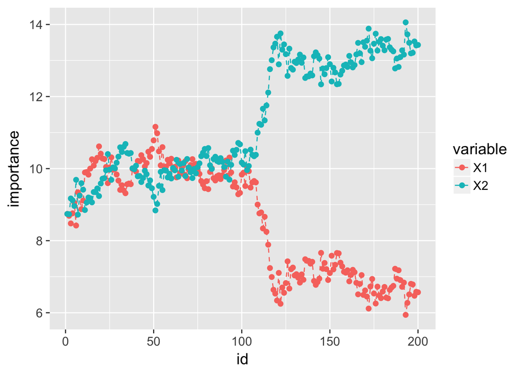

```r
# plot importance scores for diagnosis
importance.mat <- data.frame(importance.mat)
importance.mat$id <- 1:nrow(importance.mat)
colnames(importance.mat) <- c("X1","X2","id")
importance.mat <- importance.mat %>% gather(variable, importance,X1,X2)

ggplot(importance.mat,aes(x=id,y=importance,color=variable)) + geom_line(linetype = "dashed")  + geom_point(size=2)
```

Now change the window size to 5. The monitoring statistics are more noisy and raises quicker at the 101th real-time data point.

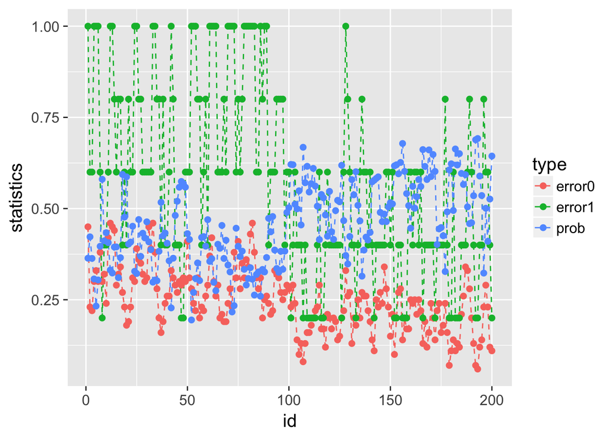

```r
# change window size to 5
wsz <- 5
result <- Monitoring( data0, data.real.time, wsz )
stat.mat <- result$stat.mat
importance.mat <- result$importance.mat

# plot different monitor statistics
stat.mat <- data.frame(stat.mat)
stat.mat$id <- 1:nrow(stat.mat)
colnames(stat.mat) <- c("error0","error1","prob","id")
stat.mat <- stat.mat %>% gather(type, statistics, error0,error1,prob)
ggplot(stat.mat,aes(x=id,y=statistics,color=type))+ geom_line(linetype = "dashed") + geom_point() + geom_point(size=2)
```

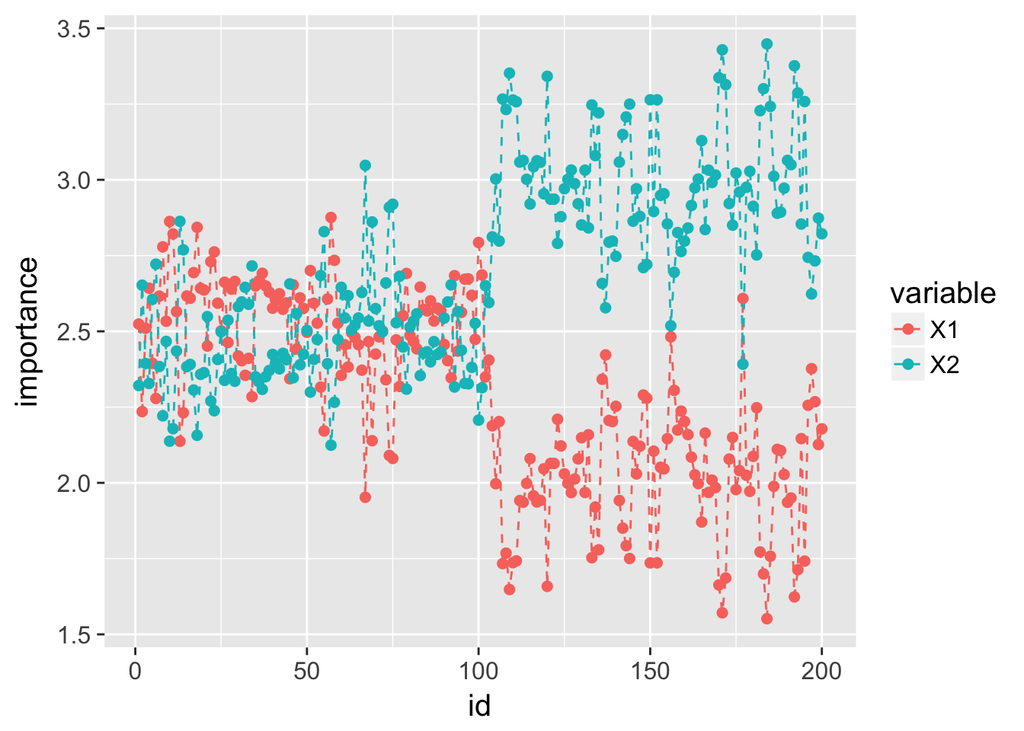

```r
# plot importance scores for diagnosis
importance.mat <- data.frame(importance.mat)
importance.mat$id <- 1:nrow(importance.mat)
colnames(importance.mat) <- c("X1","X2","id")
importance.mat <- importance.mat %>% gather(variable, importance,X1,X2)

ggplot(importance.mat,aes(x=id,y=importance,color=variable)) + geom_line(linetype = "dashed")  + geom_point(size=2)
```

```r
# 10-dimensions, with 2 variables being changed from the normal condition
dimension <- 10

# reference data
data0 <- rnorm( dimension * length0, mean = 0, sd = 1)
# real-time data with no change
data1 <- rnorm( dimension * length1, mean = 0, sd = 1)
# real-time data different from the reference data in the second the variable
data2 <- c( rnorm( (dimension - 2) * length2, mean = 0, sd = 1), rnorm( (2) * length2, mean = 20, sd = 1))


# convert to data frame
data0 <- matrix(data0, nrow = length0, byrow = TRUE) %>% as.data.frame()
data1 <- matrix(data1, nrow = length1, byrow = TRUE) %>% as.data.frame()
data2 <- matrix(data2, ncol = 10, byrow = FALSE) %>% as.data.frame()

# assign reference data with class 0 and real-time data with class 1
data0 <- data0 %>% mutate(class = 0)
data1 <- data1 %>% mutate(class = 1)
data2 <- data2 %>% mutate(class = 1)

# real-time data consists of normal data and abnormal data
data.real.time <- rbind(data1,data2)
```

10 dimensions are difficult to visualize and monitor. One can plot each variable but the difficulty of monitoring increases and the number of variables increases. However, the monitoring statistics shown below are still capable of captureing the changes. It is clear all the monitoring statistics change after the 101th real-time data point, and the importance scores also indicate the change is due to X9 and X10.

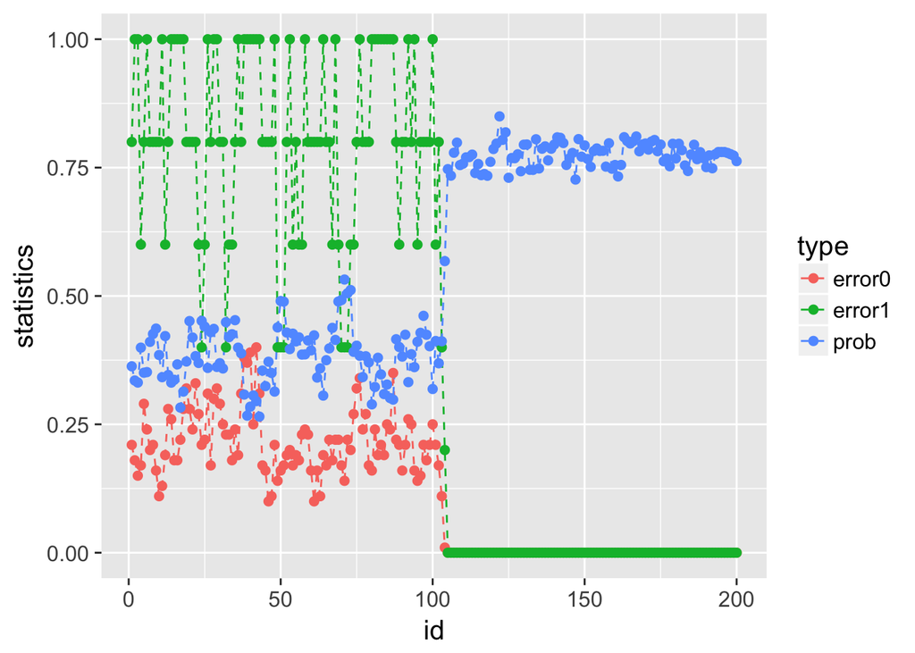

```r
result <- Monitoring( data0, data.real.time, wsz )
stat.mat <- result$stat.mat
importance.mat <- result$importance.mat

# plot different monitor statistics
stat.mat <- data.frame(stat.mat)
stat.mat$id <- 1:nrow(stat.mat)
colnames(stat.mat) <- c("error0","error1","prob","id")
stat.mat <- stat.mat %>% gather(type, statistics, error0,error1,prob)
ggplot(stat.mat,aes(x=id,y=statistics,color=type))+ geom_line(linetype = "dashed") + geom_point() + geom_point(size=2)
```

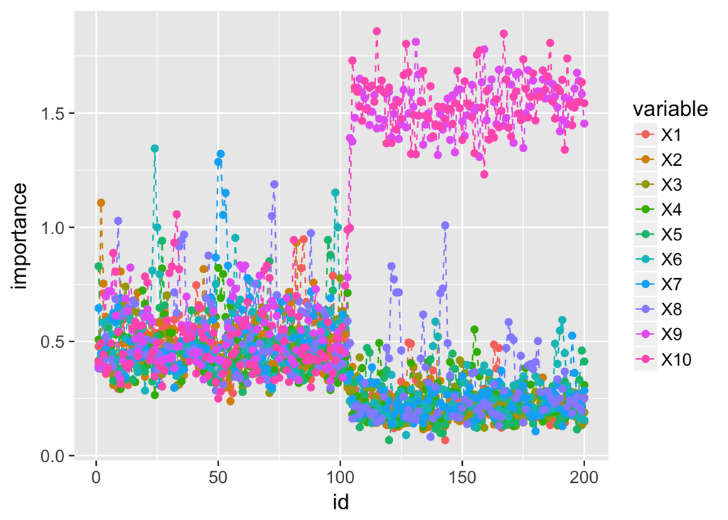

```r
# plot importance scores for diagnosis
importance.mat <- data.frame(importance.mat)
importance.mat$id <- 1:nrow(importance.mat)
# colnames(importance.mat) <- c("X1","X2","id")
importance.mat <- importance.mat %>% gather(variable, importance,X1:X10)
importance.mat$variable <- factor( importance.mat$variable, levels = paste0( "X", 1:10  ) )
# levels(importance.mat$variable) <- paste0( "X", 1:10  )
ggplot(importance.mat,aes(x=id,y=importance,color=variable)) + geom_line(linetype = "dashed")  + geom_point(size=2)
```